# visualisasi data dengan ggplot2

Muhammad Ihsan Najih Amani-Institut Teknologi Statistika dan Bisnis Muhammadiyah Semarang

2025-01-11

# 1.pengantar ggplot2

ggplot2 iku paket visualisasi data ing R sing ngadopsi konsep “Grammar of Graphics” sing dikembangake dening Leland Wilkinson. Konsep iki ngidini pangguna nggawe grafik kanthi nggabungake komponen-komponen grafis sing bisa disusun, kayata data, mapping estetis, geometri, statistik, koordinat, lan tema. Pendekatan iki nggawe proses nggawe grafik luwih fleksibel lan konsisten. ggplot2

Salah siji fitur utama ggplot2 yaiku kemampuan kanggo nggawe grafik sing kompleks kanthi sintaksis sing relatif sederhana. Pangguna bisa nambahake elemen-elemen grafis kaya titik, garis, histogram, lan liya-liyane kanthi gampang. Kajaba iku, ggplot2 nyedhiyakake kontrol sing apik kanggo kustomisasi tampilan grafik, kalebu warna, ukuran, lan tema, supaya grafik bisa disesuaikan karo kabutuhan analisis lan presentasi. Medium

ggplot2 uga nduweni komunitas pangguna sing aktif lan dokumentasi sing lengkap, kalebu buku lan tutorial online, sing nggawe proses sinau lan nggunakake paket iki luwih gampang. Kanggo sing pengin sinau luwih lanjut, buku “ggplot2: Elegant Graphics for Data Analysis” dening Hadley Wickham nyedhiyakake pandhuan lengkap babagan cara nggunakake ggplot2 kanggo nggawe grafik sing efektif lan informatif.

# 2.Dasar-dasar Materi ggplot2

## 2.1 kegunaan ggplot2

`ggplot2 adhedhasar konsep “Grammar of Graphics” sing ngidini pangguna nggawe grafik kanthi nggabungake komponen-komponen grafis sing bisa disusun. Komponen utama ing ggplot2 kalebu:

- **Data**: Dataset sing bakal dianalisis.
- **Mapping Estetis**: Cara variabel ing data dipetakan menyang elemen visual kaya posisi, warna, ukuran, lan bentuk.
- **Geometri (Geoms)**: Elemen visual sing ngwakili data, kayata titik (`geom_point()`), garis (geom_line()), histogram (geom_histogram()), lan liya-liyane.
- **Statistik**: Transformasi data sing ditindakake sadurunge plotting, kayata agregasi utawa normalisasi.
- **Koordinat**: Sistem koordinat sing digunakake kanggo nampilake data, kayata koordinat Cartesian standar utawa koordinat polar.
- **Tema**: Kustomisasi tampilan grafik, kalebu elemen-elemen kaya latar mburi, gridlines, lan font.

# 3.Berikut adalah contoh input dan outputnya:

## 3.1 Berikut contoh implementasi plottitik

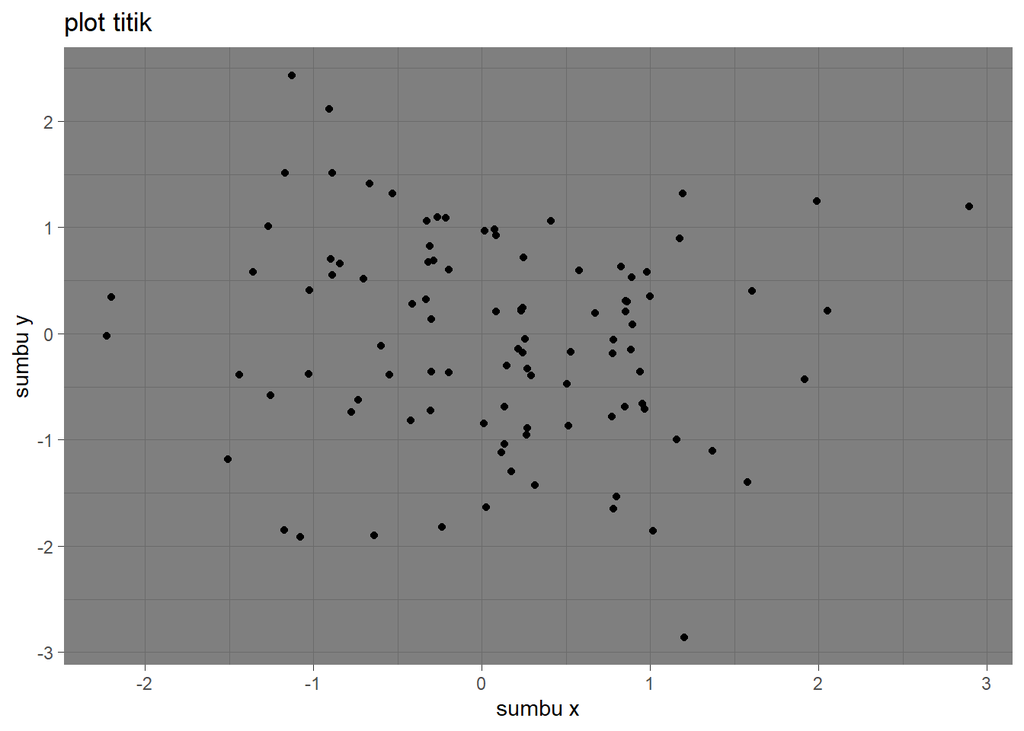

```r
#muat library ggplot2
library(ggplot2)

#buat data frame contoh
data <- data.frame(x = rnorm(100), y = rnorm(100))

#buat plot titik
ggplot(data, aes (x = x, y = y )) +

#buat plot titik dengan label dan tema kustom
geom_point() +
  labs(title = "plot titik", x = "sumbu x", y = "sumbu y") +
  theme_dark()
```

## 3.2 Berikut contoh implementasi Faceted Plot dengan 4 Warna

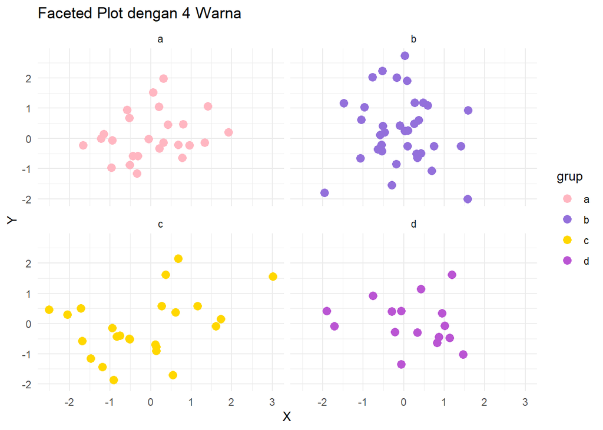

```r
# Buat data frame
data <- data.frame(
  x = rnorm(100),
  y = rnorm(100),
  grup = sample(letters[1:4], 100, replace = TRUE)  # Kelompok: "a", "b", "c", "d"
)

# Plot dengan tema 1 warna
library(ggplot2)

ggplot(data, aes(x = x, y = y, color = grup)) +
  geom_point(size = 3) +
  facet_wrap(~ grup) +
  scale_color_manual(values = c(
    "a" = "#FFB6C1",  # Pink lembut (inspirasi warna rambut Yae Miko)
    "b" = "#9370DB",  # Ungu medium (tema Electro Vision)
    "c" = "#FFD700",  # Emas (aksen detail Yae Miko)
    "d" = "#BA55D3"   # Ungu gelap (kekuatan elegan)
  )) +
  theme_minimal() +
  labs(
    title = "Faceted Plot dengan 4 Warna",
    x = "X",
    y = "Y"
  )
```

# 4. Tampilan Read data Lizards.csv

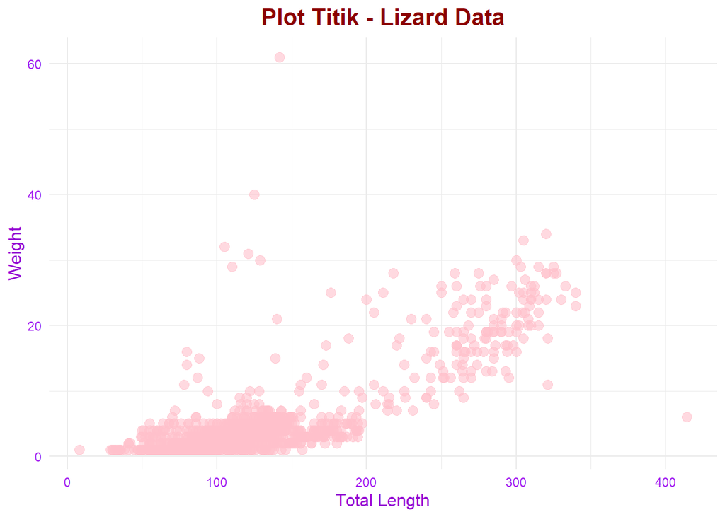

```r
library(readr)
lizards <- read.csv("lizards.csv")
View(lizards)
# Load library ggplot2
library(ggplot2)

# Ngeload data
lizards <- read.csv("lizards.csv")

# Tampilin data
View(lizards)

# Nggunakake ggplot kanggo plot data
ggplot(lizards, aes(x = total_length, y = weight)) +
  geom_point(color = "pink", size = 3, alpha = 0.6) +  # Titik nganggo warna pink
  labs(title = "Plot Titik - Lizard Data", x = "Total Length", y = "Weight") +
  theme_minimal() +  # Tema minimalis
  theme(
    plot.title = element_text(hjust = 0.5, size = 16, face = "bold", color = "darkred"),  # Judul nganggo warna merah tua
    axis.title = element_text(size = 12, color = "darkviolet"),  # Judul sumbu nganggo ungu
    axis.text = element_text(color = "purple")  # Teks axis nganggo ungu
  )
```

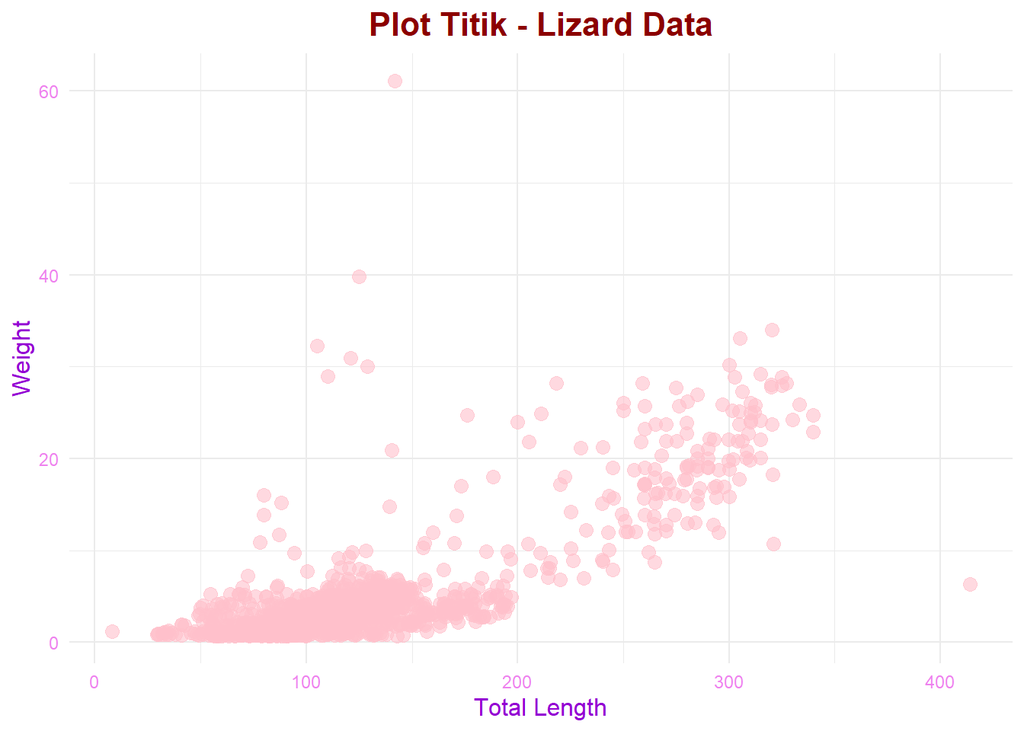

```r
# Load library ggplot2
library(ggplot2)

# Load data
lizards <- read.csv("lizards.csv")

# Display data
View(lizards)

# Use ggplot to plot data with jitter
ggplot(lizards, aes(x = total_length, y = weight)) +
  geom_jitter(color = "pink", size = 3, alpha = 0.6, width = 0.3, height = 0.3) +  # Use geom_jitter to spread points
  labs(title = "Plot Titik - Lizard Data", x = "Total Length", y = "Weight") +
  theme_minimal() +  # Minimalist theme
  theme(
    plot.title = element_text(hjust = 0.5, size = 16, face = "bold", color = "darkred"),  # Title with dark red color
    axis.title = element_text(size = 12, color = "darkviolet"),  # Axis titles with dark violet color
    axis.text = element_text(color = "violet")  # Axis text with red color
  )
```

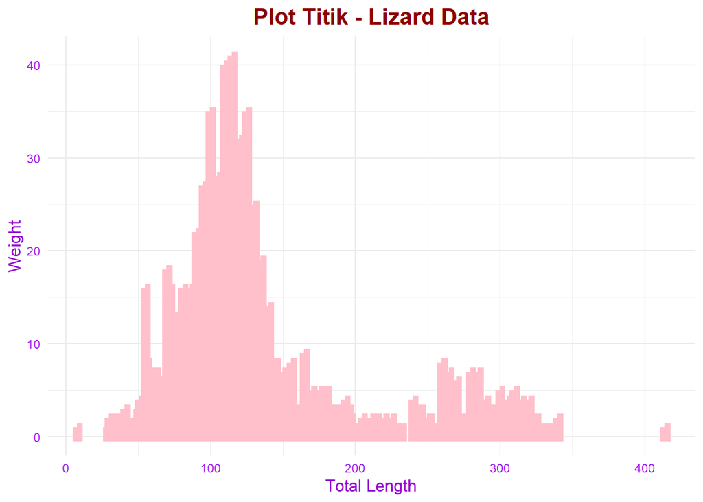

[output not shown]

```r
# Load library ggplot2
library(ggplot2)

# Ngeload data
lizards <- read.csv("lizards.csv")

# Tampilin data
View(lizards)

# Nggunakake ggplot kanggo plot data
ggplot(lizards, aes(x = total_length,)) +
  geom_bar(color = "pink", size = 3, alpha = 0.6) +  # Titik nganggo warna pink
  labs(title = "Plot Titik - Lizard Data", x = "Total Length", y = "Weight") +
  theme_minimal() +  # Tema minimalis
  theme(
    plot.title = element_text(hjust = 0.5, size = 16, face = "bold", color = "darkred"),  # Judul nganggo warna merah tua
    axis.title = element_text(size = 12, color = "darkviolet"),  # Judul sumbu nganggo ungu
    axis.text = element_text(color = "purple")  # Teks axis nganggo ungu
  )
```

```r
View(iris)
```

# Referensi

-rmarkdown -open AI -kawa-kawa